# ESD_RedWineQuality

Osama El Bakr

January 4, 2019

# Explore and Summarize Data Project - Red Wine Quality Data Set

This tidy data set contains 1,599 red wines with 11 variables on the chemical properties of the wine. At least 3 wine experts rated the quality of each wine, providing a rating between 0 (very bad) and 10 (very excellent).

```
##                    X        fixed.acidity     volatile.acidity
##                    0                    0                    0
##          citric.acid       residual.sugar            chlorides
##                    0                    0                    0
##  free.sulfur.dioxide total.sulfur.dioxide              density
##                    0                    0                    0
##                   pH            sulphates              alcohol
##                    0                    0                    0
##              quality
##                    0
```

# 1- Univariate Plots Section

```
## [1] 1599   13
```

```
## 'data.frame':    1599 obs. of  13 variables:
##  $ X                   : int  1 2 3 4 5 6 7 8 9 10 ...
##  $ fixed.acidity       : num  7.4 7.8 7.8 11.2 7.4 7.4 7.9 7.3 7.8 7.5 ...
##  $ volatile.acidity    : num  0.7 0.88 0.76 0.28 0.7 0.66 0.6 0.65 0.58 0.5 ...
##  $ citric.acid         : num  0 0 0.04 0.56 0 0 0.06 0 0.02 0.36 ...
##  $ residual.sugar      : num  1.9 2.6 2.3 1.9 1.9 1.8 1.6 1.2 2 6.1 ...
##  $ chlorides           : num  0.076 0.098 0.092 0.075 0.076 0.075 0.069 0.065 0.073 0.071 ...
##  $ free.sulfur.dioxide : num  11 25 15 17 11 13 15 15 9 17 ...
##  $ total.sulfur.dioxide: num  34 67 54 60 34 40 59 21 18 102 ...
##  $ density             : num  0.998 0.997 0.997 0.998 0.998 ...
##  $ pH                  : num  3.51 3.2 3.26 3.16 3.51 3.51 3.3 3.39 3.36 3.35 ...
##  $ sulphates           : num  0.56 0.68 0.65 0.58 0.56 0.56 0.46 0.47 0.57 0.8 ...
##  $ alcohol             : num  9.4 9.8 9.8 9.8 9.4 9.4 9.4 10 9.5 10.5 ...
##  $ quality             : int  5 5 5 6 5 5 5 7 7 5 ...
```

```
##        X          fixed.acidity   volatile.acidity  citric.acid
##  Min.   :   1.0   Min.   : 4.60   Min.   :0.1200   Min.   :0.000
##  1st Qu.: 400.5   1st Qu.: 7.10   1st Qu.:0.3900   1st Qu.:0.090
##  Median : 800.0   Median : 7.90   Median :0.5200   Median :0.260
##  Mean   : 800.0   Mean   : 8.32   Mean   :0.5278   Mean   :0.271
##  3rd Qu.:1199.5   3rd Qu.: 9.20   3rd Qu.:0.6400   3rd Qu.:0.420
##  Max.   :1599.0   Max.   :15.90   Max.   :1.5800   Max.   :1.000
##  residual.sugar     chlorides       free.sulfur.dioxide
##  Min.   : 0.900   Min.   :0.01200   Min.   : 1.00
##  1st Qu.: 1.900   1st Qu.:0.07000   1st Qu.: 7.00
##  Median : 2.200   Median :0.07900   Median :14.00
##  Mean   : 2.539   Mean   :0.08747   Mean   :15.87
##  3rd Qu.: 2.600   3rd Qu.:0.09000   3rd Qu.:21.00
##  Max.   :15.500   Max.   :0.61100   Max.   :72.00
##  total.sulfur.dioxide    density             pH          sulphates
##  Min.   :  6.00       Min.   :0.9901   Min.   :2.740   Min.   :0.3300
##  1st Qu.: 22.00       1st Qu.:0.9956   1st Qu.:3.210   1st Qu.:0.5500
##  Median : 38.00       Median :0.9968   Median :3.310   Median :0.6200
##  Mean   : 46.47       Mean   :0.9967   Mean   :3.311   Mean   :0.6581
##  3rd Qu.: 62.00       3rd Qu.:0.9978   3rd Qu.:3.400   3rd Qu.:0.7300
##  Max.   :289.00       Max.   :1.0037   Max.   :4.010   Max.   :2.0000
##     alcohol         quality
##  Min.   : 8.40   Min.   :3.000
##  1st Qu.: 9.50   1st Qu.:5.000
##  Median :10.20   Median :6.000
##  Mean   :10.42   Mean   :5.636
##  3rd Qu.:11.10   3rd Qu.:6.000
##  Max.   :14.90   Max.   :8.000
```

```
##
##   3   4   5   6   7   8
##  10  53 681 638 199  18
```

- quality is the main variable of interest here in the data, I am asking, What is distribution for the quality ?

```
##    Min. 1st Qu.  Median    Mean 3rd Qu.    Max.
##   3.000   5.000   6.000   5.636   6.000   8.000
```

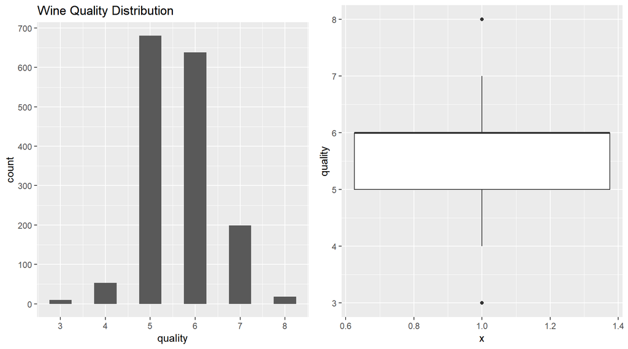

- Quality is normally distributed, data range from 3 to 8, most values between 5 & 6

- fixed.acidity distribution

```
##    Min. 1st Qu.  Median    Mean 3rd Qu.    Max.
##    4.60    7.10    7.90    8.32    9.20   15.90
```

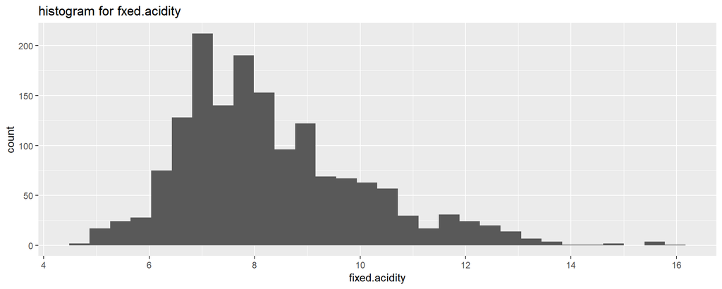

- fixed.acidity distribution is skewed right, so transform x-axis into log scale to make it likely normal distributed.

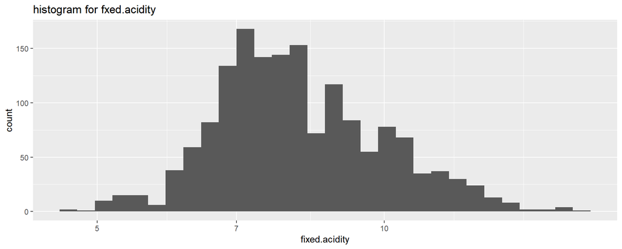

- volatile.acidity

```
##    Min. 1st Qu.  Median    Mean 3rd Qu.    Max.
##  0.1200  0.3900  0.5200  0.5278  0.6400  1.5800
```

- volatile.acidity most values range between 0.3 and 0.7, and distribution is skewed right with outliers, so when zoom in to values less than 1, the distribution seems to be normallly distributed.

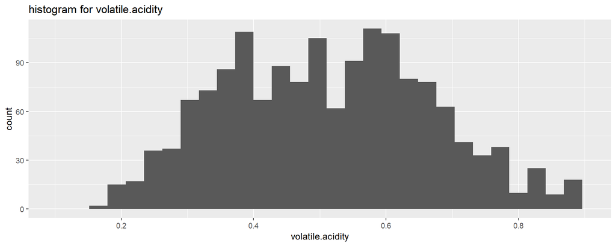

- citric.acid

```
##    Min. 1st Qu.  Median    Mean 3rd Qu.    Max.
##   0.000   0.090   0.260   0.271   0.420   1.000
```

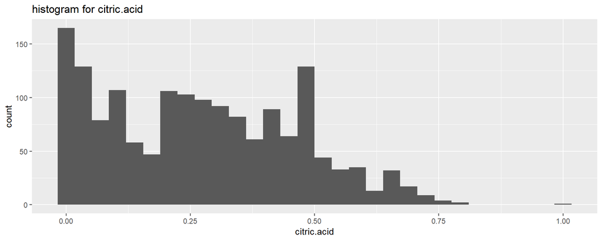

- citric.acid distribution is skewed right, so ransform x-axis into sqrt scale to make it likely normal distributed.

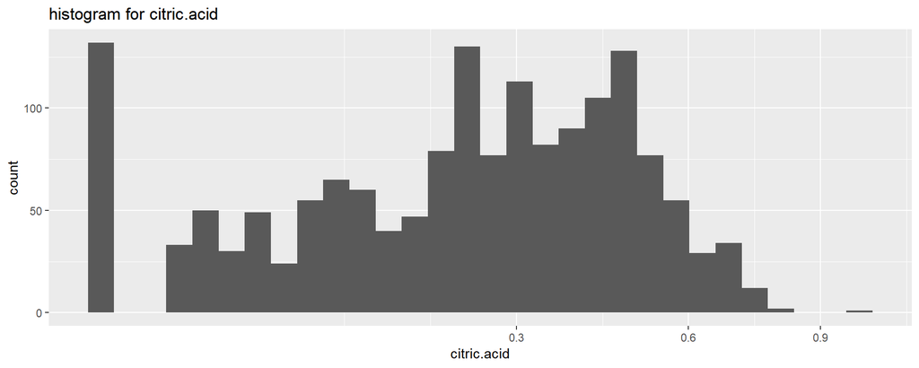

- residual.sugar

```
##    Min. 1st Qu.  Median    Mean 3rd Qu.    Max.
##   0.900   1.900   2.200   2.539   2.600  15.500
```

- residual.sugar most values range between 1 and 5, and distribution is skewed right with outliers, so when zoom in to values less than 5, the distribution seems to be normallly distributed.

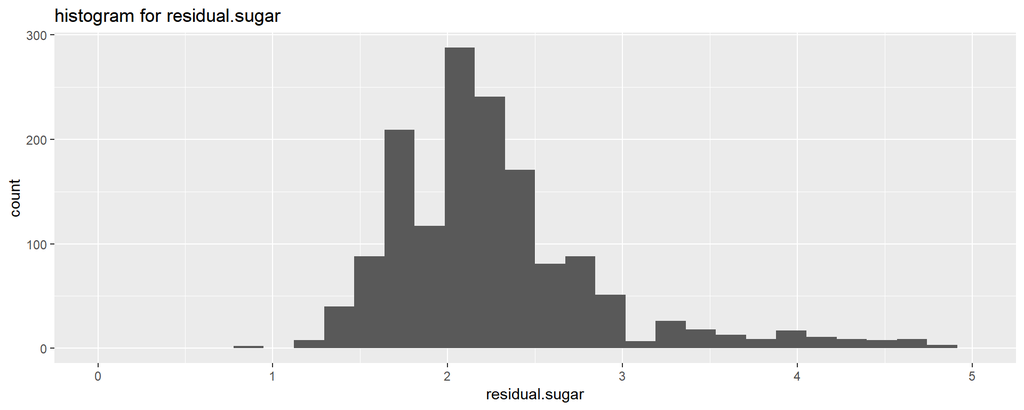

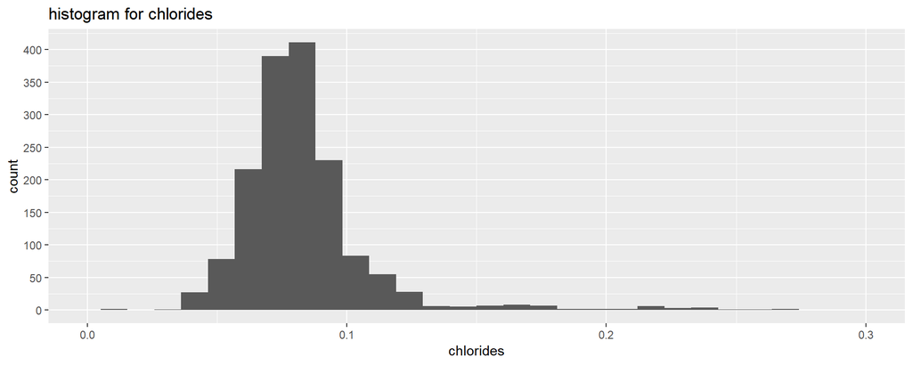

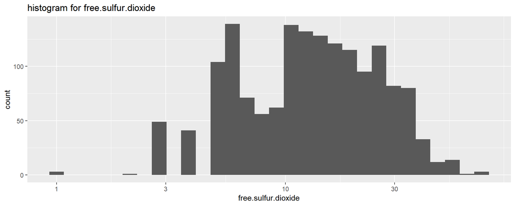

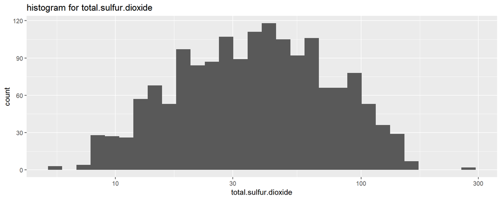

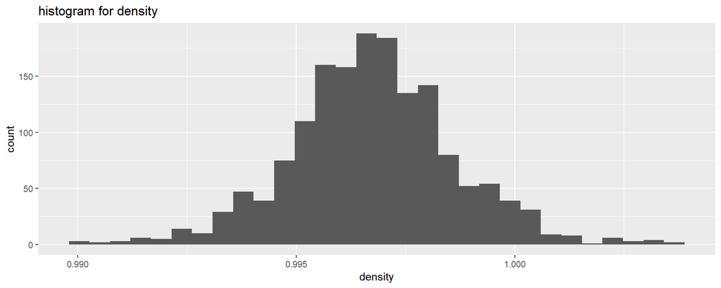

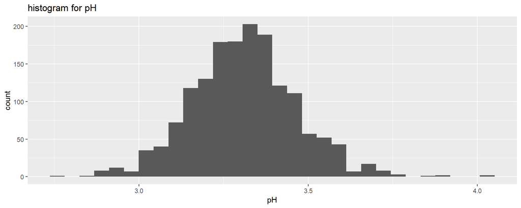

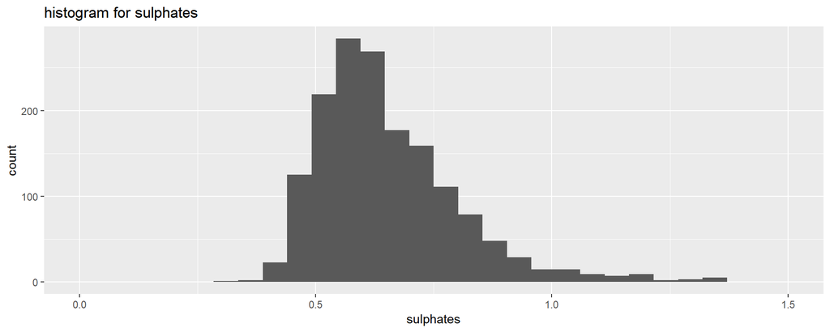

- alcohol

```
##    Min. 1st Qu.  Median    Mean 3rd Qu.    Max.
##    8.40    9.50   10.20   10.42   11.10   14.90
```

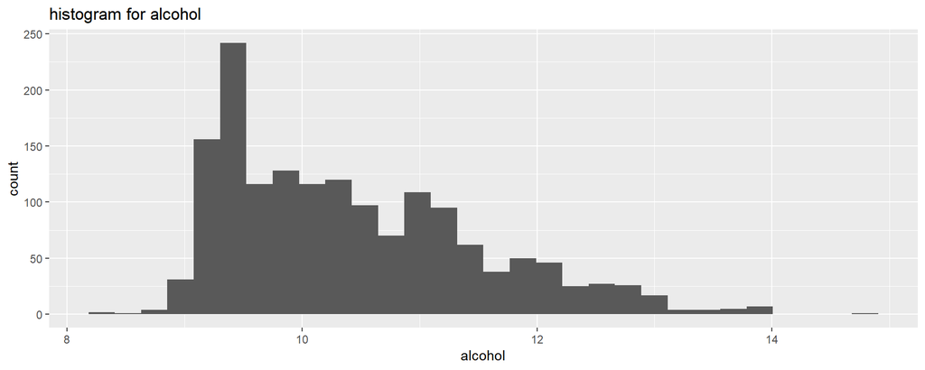

- alcohol values range from 8.4 and 14.9. alcohol distribution skewed right. with most of values between 9.5 and 11.

# 2 - Univariate Analysis

### What is the structure of your dataset?

```
This is a tidy data set contains 1,599 red wines with 11 variables on the chemical properties of the wine.
At least 3 wine experts rated the quality of each wine, providing a rating between 0 (very bad) and 10 (very excellent)
```

### What is/are the main feature(s) of interest in your dataset?

```
The main feature is the quality. I want to explore the date to find which of the other variables has the most affect on the quality and the types of relations.
```

### What other features in the dataset do you think will help support your investigation into your feature(s) of interest?

```
Alcohol and pH and other 9 variables are likely to contribute to the quality of the wine. I will continue investigation into date to find relation between            different attributes and quality.
```

### Did you create any new variables from existing variables in the dataset?

```
I did not create any new variables, as i beleive there is no need.
```

### Of the features you investigated, were there any unusual distributions? Did you perform any operations on the data to tidy, adjust, or change the form of the data? If so, why did you do this?

[output not shown]

# 3- Bivariate Plots Section

I have a question, What is most variable has effect on quality ? I will create the matrix table to show relationship between the different variables - Correlation matrix

```
##                      fixed.acidity volatile.acidity citric.acid
## fixed.acidity                 1.00            -0.26        0.67
## volatile.acidity             -0.26             1.00       -0.55
## citric.acid                   0.67            -0.55        1.00
## residual.sugar                0.11             0.00        0.14
## chlorides                     0.09             0.06        0.20
## free.sulfur.dioxide          -0.15            -0.01       -0.06
## total.sulfur.dioxide         -0.11             0.08        0.04
## density                       0.67             0.02        0.36
## pH                           -0.68             0.23       -0.54
## sulphates                     0.18            -0.26        0.31
## alcohol                      -0.06            -0.20        0.11
## quality                       0.12            -0.39        0.23
##                      residual.sugar chlorides free.sulfur.dioxide
## fixed.acidity                  0.11      0.09               -0.15
## volatile.acidity               0.00      0.06               -0.01
## citric.acid                    0.14      0.20               -0.06
## residual.sugar                 1.00      0.06                0.19
## chlorides                      0.06      1.00                0.01
## free.sulfur.dioxide            0.19      0.01                1.00
## total.sulfur.dioxide           0.20      0.05                0.67
## density                        0.36      0.20               -0.02
## pH                            -0.09     -0.27                0.07
## sulphates                      0.01      0.37                0.05
## alcohol                        0.04     -0.22               -0.07
## quality                        0.01     -0.13               -0.05
##                      total.sulfur.dioxide density    pH sulphates alcohol
## fixed.acidity                       -0.11    0.67 -0.68      0.18   -0.06
## volatile.acidity                     0.08    0.02  0.23     -0.26   -0.20
## citric.acid                          0.04    0.36 -0.54      0.31    0.11
## residual.sugar                       0.20    0.36 -0.09      0.01    0.04
## chlorides                            0.05    0.20 -0.27      0.37   -0.22
## free.sulfur.dioxide                  0.67   -0.02  0.07      0.05   -0.07
## total.sulfur.dioxide                 1.00    0.07 -0.07      0.04   -0.21
## density                              0.07    1.00 -0.34      0.15   -0.50
## pH                                  -0.07   -0.34  1.00     -0.20    0.21
## sulphates                            0.04    0.15 -0.20      1.00    0.09
## alcohol                             -0.21   -0.50  0.21      0.09    1.00
## quality                             -0.19   -0.17 -0.06      0.25    0.48
##                      quality
## fixed.acidity           0.12
## volatile.acidity       -0.39
## citric.acid             0.23
## residual.sugar          0.01
## chlorides              -0.13
## free.sulfur.dioxide    -0.05
## total.sulfur.dioxide   -0.19
## density                -0.17
## pH                     -0.06
## sulphates               0.25
## alcohol                 0.48
## quality                 1.00
```

- I just show this table for the vareity of exploration but it I prefer to use plotting for better visualization.

### Plot matrix

I will user it to show correlation between the different variables and have a better look for positive or negative correlations also the strong or weak relations.

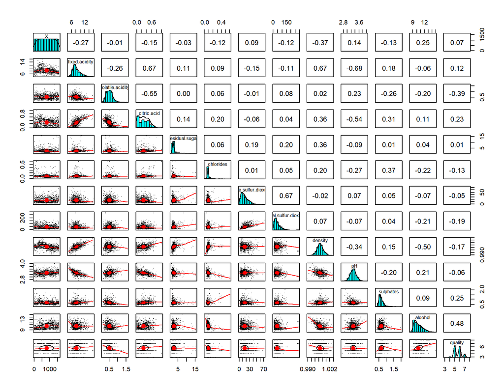

- I can see here most values show weak/moderate correlations, I was looking for any strong correlation between my variable of interest (Quality) with other variables, but what i found was not as I excpected , as the strongest correlation between quality and variables was that with alcohol by 0.48 positively. but some variables seems to be more strongly correlated as, fixed.acidity and citric.acid at 0.67 positively correlated. And fixed.acidity with density at the same value. also for the fixed.acidity strongly correlate negatively with pH with -0.68.

### Correlation Plot

- I will use here (corrplot) for better visualization with colors, as relations with high concentration of color represent stronger corrlation, with blue color represents positive and red color represents negative.

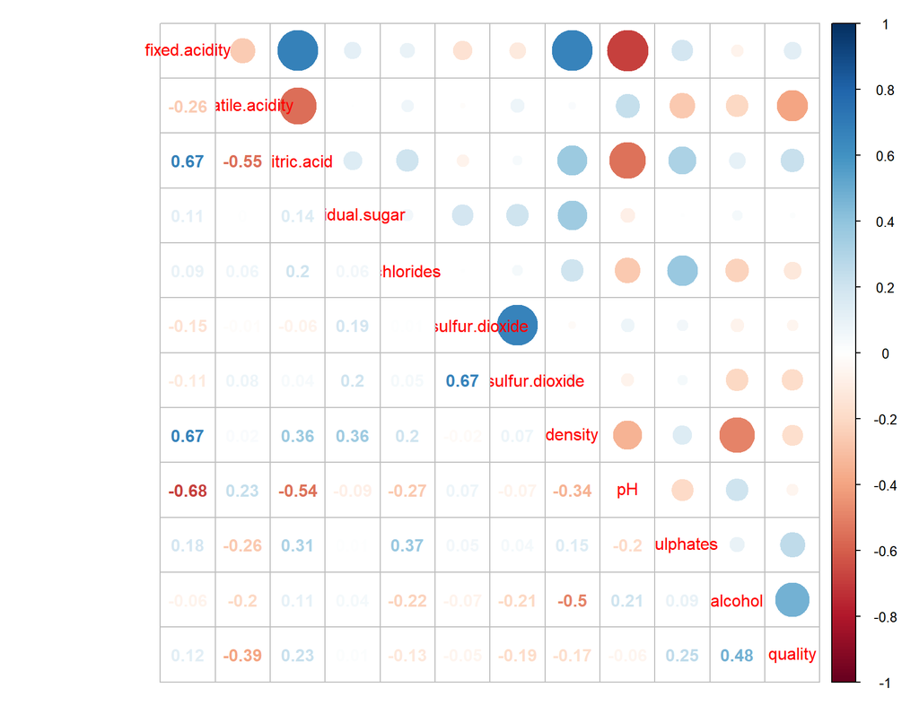

- I can see now the same result as the previous plot but more easily, the strongest correlation between quality and variables was that with alcohol by 0.48 correlation coefficient . but some variables seems to be more strongly correlated as, fixed.acidity and citric.acid at 0.67 positively correlated. And fixed.acidity with density at the same value. also for the fixed.acidity strongly correlate negatively with pH with -0.68. free.sulfur.dioxide and total.sulfur.dioxide tend to be positively correlated by 0.67.
- I wanted here to explore more about the relation between quality and some variables i beleive the may has an affect on the quality
- Boxplots for quality and some other variables

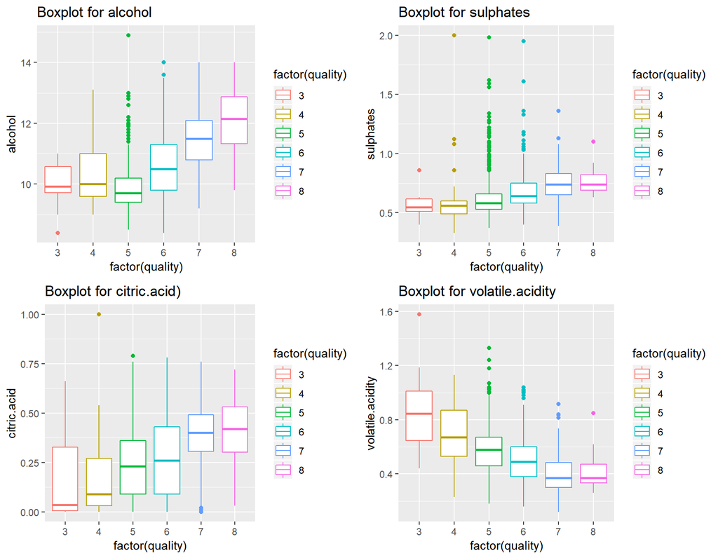

- When alcohol values increases between 11 and 13 wine tend te bo in a higher quality at 7 and 8, and also with citric.acid values increases between 0.25 and 0.55. While volatile.acidity values at the most high values between 0.6 to 0.10 wine tend to be in low quality at 3 and 4.
- We can see here that alcohol has the most positive correlation with quality, The higher the alcohol, the higher the quality. in other hand volatile.acidity has the most negative correlation with quality.

# 4- Bivariate Analysis

### Talk about some of the relationships you observed in this part of the investigation. How did the feature(s) of interest vary with other features in the dataset?

I found here these correlation : The quality tend to correlate positively with Alcohol. The quality tend to correlate negatively with volatile.acidity. The quality tend to moderately correlate positively with sulphates and citric.acid. The higher the alcohol, the higher the quality. The higher the sulphates, the higher the quality. The higher the citric.acid, the higher the quality. The higher the volatile.acidity, the lower the quality.

### Did you observe any interesting relationships between the other features (not the main feature(s) of interest)?

The fixed.acidity with citric.acid or with density tend to be positivelycorrelated with each other, The fixed.acidity tend to correlate negatively with pH.

### What was the strongest relationship you found?

From the perspective of the feature of interest (Quality), it seems that it is the positive relation with Alcohol and negatively with volatile.acidity.

# 5- Multivariate Plots Section

I will here try to explore the relation between different variables regarding the variable of ineterst

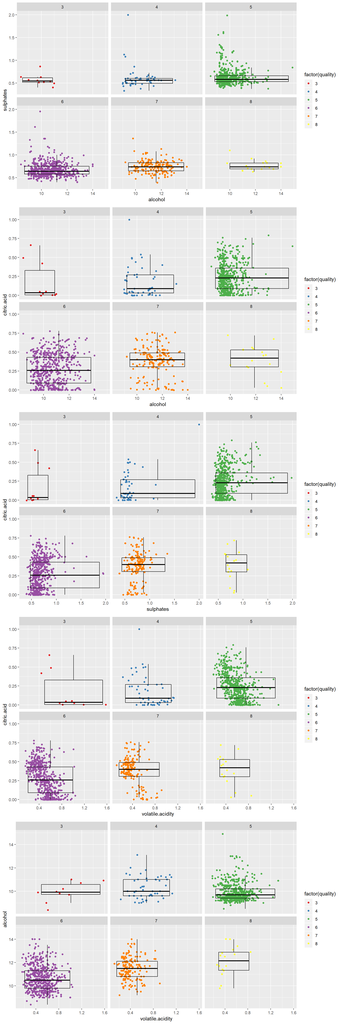

- As i see the distribution for the quality, low quality wines are more concentrated with alcohol less than 10, sulphates less than 0.7, citric.acid less than 0.1.
- From the previous plots i can see some results as, at some points wine be in high quality with high levels of alcoho and low levels of volatile.acidity.

# 6- Multivariate Analysis

### Talk about some of the relationships you observed in this part of the investigation. Were there features that strengthened each other in terms of looking at your feature(s) of interest?

- Wine with low quality appears with low alcohol and low sulphates
- Wine with high quality appears with high alcohol and moderate level of citric.acid
- Wine with high quality appears with low volatile.acidity and hight citric.acid
- Wine with high quality appears with low volatile.acidity and high alcohol

# 7- Final Plots and Summary

### Plot one

- Quality distribution with percentage

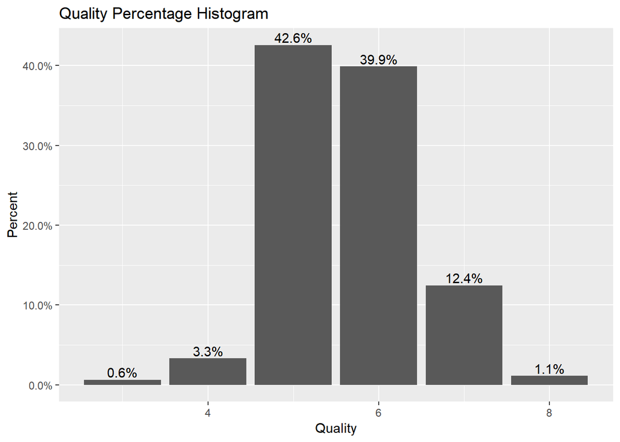

### Description One

- I chosed this because the quality is my variable of interest.
- Quality range 3 to 8, most values between 5 & 6.
- Wine with bad or low quality and wines with great quality not existed enough here in the dataset.i beleive this affects the results.

### Plot Two

- Correlation between alcohol and quality

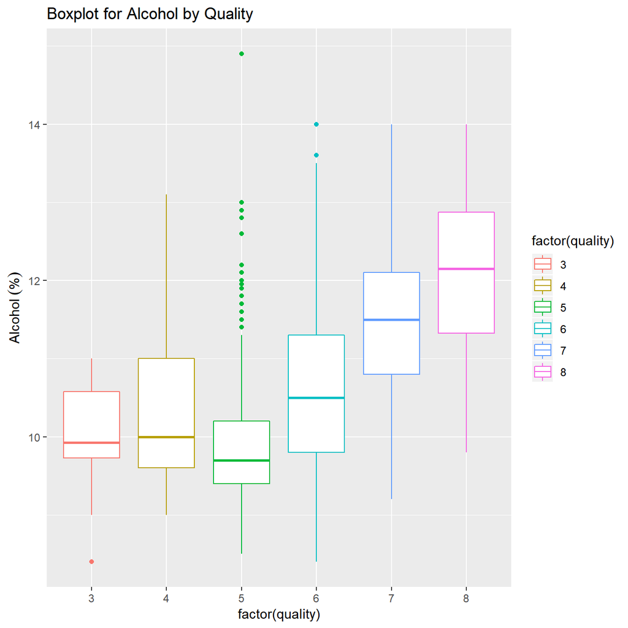

### Description Two

This shows the relation between alcohol and quality, It reflects that The higher the alcohol, the higher the quality. The quality tend to correlate positively with Alcohol.

### Plot three

- Correlation between alcohol and aulphates grouped by quality

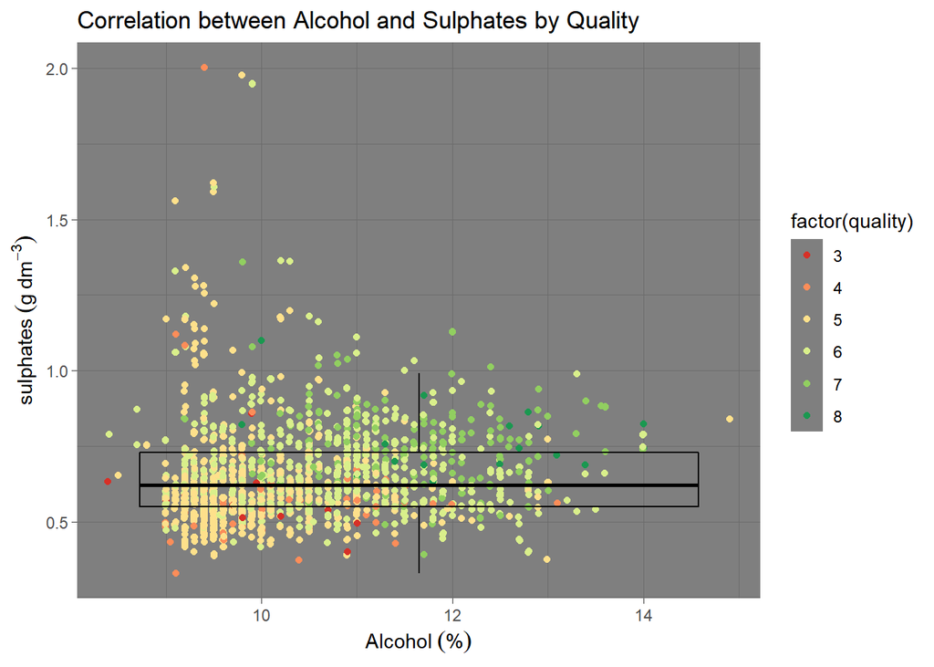

### Description Three

- I chosed this because it shows how that Wine with low quality appears with low levels of alcohol and low levels of sulphates.
- Quality is positively correlated with alcohol, and there is weak correlation between alcohol and sulphates.
- I observed that Wine with high level alcohol and medium level of sulphates seems to be a high quality wine.

# Reflection

This data set contains date about 1,599 red wines with 11 variables on the chemical properties of the wine.

I invistegated the data to define my points of interest, then decided to be the quality variable.

I made plots to show distribution for all variables in data,

The tranformed distribution seems to be more likely normallly distributed.

I tried to figure out which variables that has the most effect on Quality variable.

I made plot matrix to show relationship between the different variables

I found here these correlation :

```
- The quality tend to correlate positively with Alcohol.

- The quality tend to correlate negatively with volatile.acidity.
```

Then I continued explore the relation between different variables regardin the variable of ineterst (quality)

I found some results as that Wine with low quality appears with low alcohol and low sulphates.

But I did not a very strong correlation between a single variable with quality,

and also i think data is not complete as most of wine quality range between just two values.

- My idea about this exploration :

I think that Data Set need to be updated with more records to impact a more strong correlations, and if more attributes added like rating based on customers, prices and backaging quality will help to find better insights about Quality.